# Course_2_Week1_Lecture_Notes

Zhenzhuo A. C.

26.03.22

### Two Basic Operators <- and :

1. <- is called the “assignment operator”, which assigns a value to a symbol
- **example**:

```r
x<-1
x
```

```
## [1] 1
```

The created symbol is called x, and the assigned value is 1. “x is 1” is a R expression.

At the same time, x is a numeric object with 1 element.

- **another example**:

```r
msg <- "hello"
msg
```

```
## [1] "hello"
```

msg is also a symbol assigned to the string *hello*, making msg a character vector.

- **special case with ##**

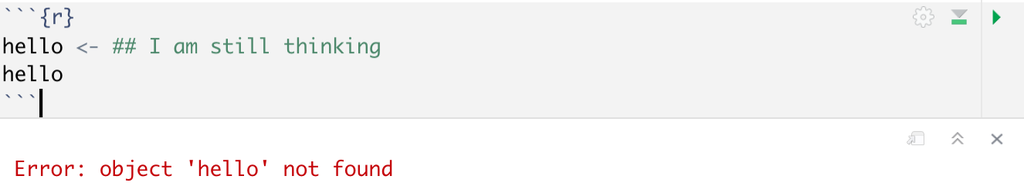

Everything on the right side of double hash is comments. In the above expression, no value has been assigned to the symbol *hello*. Therefore, there is no print-out result.

2. : is the operator for integer sequences creation.

```r
x <- 1:20
x
```

```
##  [1]  1  2  3  4  5  6  7  8  9 10 11 12 13 14 15 16 17 18 19 20
```

### Data Types in R

#### Atomic classes

R has 5 basic “atomic” classes of objects:  
1. character  
2. numeric (real numbers)  
3. integer  
4. complex  
5. logical (TRUE/FALSE)

#### Data Type: Vectors

The most basic factor in R is a vector that **only** contains **objects of the same class**

Vectors can be created using vector() function. E.g. An numeric vector with length = 10 by default.

```r
x<-vector("numeric", length = 10)
x
```

```
##  [1] 0 0 0 0 0 0 0 0 0 0
```

The c() function can also be used to create vectors of objects.

```r
x<- c(0.5, 0.6)
class(x)
```

```
## [1] "numeric"
```

```r
z<- c(TRUE, FALSE) ##logical
class(z)
```

```
## [1] "logical"
```

```r
u <- c(T, F)
class(u)
```

```
## [1] "logical"
```

```r
v<- c("a","b","c")
class(v)
```

```
## [1] "character"
```

```r
w<- 9:20
class(w)
```

```
## [1] "integer"
```

```r
k<-c(1+0i, 2+4i)
class(k)
```

```
## [1] "complex"
```

#### Data Type: Lists

```r
m<- c(1.7, "a")
class(m)
```

```
## [1] "character"
```

```r
n<-c(TRUE,2)
class(n)
```

```
## [1] "numeric"
```

The reason why number 2 is the least denominator because TRUE and FALSE these 2 logical objects symbolize number 1 and 0.

```r
p<-c("a", TRUE)
class(p)
```

```
## [1] "character"
```

The output of a list separate every element because they are not of a same class.

```r
q<-list(1, "a", TRUE, 1+4i)
q
```

```
## [[1]]
## [1] 1
##
## [[2]]
## [1] "a"
##
## [[3]]
## [1] TRUE
##
## [[4]]
## [1] 1+4i
```

#### Data Type: Number

Numbers are generally numeric objects. NaN represents undefined value.

#### Data Type: Attributes

Attributes can also be objects in R.

1. names, dimnames (i.e. dimension names)
2. dimensions (e.g. matrices: number of columns and rows symbolizes dimensions; multidimensional arrays)
3. class
4. length
5. other user-defined attributes/metadata (what you can define separately for an object using various attribute functions)
- Attributes can be accessed using attributes() function.
- Every object has a class and length. For vectors it is very obvious: the length of the object equals the number of elements in the vector.

##### Explicit Coercion between Classes in Vector

Using the as.numeric(), as.logical(), as.character() function, respectively, to convert the vector to your wished class.

```r
r<-0:6
r
```

```
## [1] 0 1 2 3 4 5 6
```

```r
class(r)
```

```
## [1] "integer"
```

```r
as.logical(r)
```

```
## [1] FALSE  TRUE  TRUE  TRUE  TRUE  TRUE  TRUE
```

```r
as.character(r)
```

```
## [1] "0" "1" "2" "3" "4" "5" "6"
```

However, coercion does not work always:

```r
t<-c("a","b","c")
as.numeric(t)
```

```
## [1] NA NA NA
```

```r
as.logical(t)
```

```
## [1] NA NA NA
```

```r
as.complex(t)
```

```
## [1] NA NA NA
```

if the coercion does not work, the output will be NA.

#### Data Type: Matrices

Matrices are vectors with a dimension attribute. The dimension attribute is itself an integer vector of length 2, namely (nrow, ncol).  
- You can use matrix() function to create a matrix.  
- dim() function to check the dimension.  
- attribute() function to convert the dimension to a vector.

```r
a <- matrix(nrow = 2, ncol = 3)
a
```

```
##      [,1] [,2] [,3]
## [1,]   NA   NA   NA
## [2,]   NA   NA   NA
```

```r
dim(a)
```

```
## [1] 2 3
```

```r
attributes(a)
```

```
## $dim
## [1] 2 3
```

When assigning the values, matrices are constructed *column-wise*

```r
b<-matrix(1:6, nrow = 2, ncol = 3)
b
```

```
##      [,1] [,2] [,3]
## [1,]    1    3    5
## [2,]    2    4    6
```

And we can also use dim() to convert a vector to a matrix.

```r
e<-1:10
dim(e) = c(2,5)
e
```

```
##      [,1] [,2] [,3] [,4] [,5]
## [1,]    1    3    5    7    9
## [2,]    2    4    6    8   10
```

Another way to create matrices is to use column binding or row binding.

```r
e<-1:10
f<-2:11
cbind(e,f)
```

```
##        e  f
##  [1,]  1  2
##  [2,]  2  3
##  [3,]  3  4
##  [4,]  4  5
##  [5,]  5  6
##  [6,]  6  7
##  [7,]  7  8
##  [8,]  8  9
##  [9,]  9 10
## [10,] 10 11
```

```r
rbind(e,f)
```

```
##   [,1] [,2] [,3] [,4] [,5] [,6] [,7] [,8] [,9] [,10]
## e    1    2    3    4    5    6    7    8    9    10
## f    2    3    4    5    6    7    8    9   10    11
```

### Data Type: Factors

Factors are used to represent categorical data, which can be ordered or unordered. 1. integer factor where each integer has a label (e.g. 1 represents “high, 2 represents”medium”, 3 represents “low”) 2. professor, associated professor, visiting professor… (categorical but ordered)

```r
g <- factor(c("no", "no", "yes","no","yes"))
g
```

```
## [1] no  no  yes no  yes
## Levels: no yes
```

The two levels of this factor are “no” and “yes”.

Use table() function to count the frequency of these two levels:

```r
table(g)
```

```
## g
##  no yes
##   3   2
```

The unclass() function strips out the class of a factor:

```r
unclass(g)
```

```
## [1] 1 1 2 1 2
## attr(,"levels")
## [1] "no"  "yes"
```

The order of levels can be set using *levels* argument to a factor. This is especially useful in linear modelling because the first level is usually used as the baseline level.

```r
g <- factor(c("no", "no", "yes","no","yes"), levels=c("yes", "no"))
g
```

```
## [1] no  no  yes no  yes
## Levels: yes no
```

### Data Type: Missing Values

Missing values are denoted by NA or NaN. NaN stands for undefined mathematical operations, while NA stands generally all missing values, including NaN.

```r
h<-c(1,2,4,NA,5,7)
is.na(h)
```

```
## [1] FALSE FALSE FALSE  TRUE FALSE FALSE
```

```r
is.nan(h)
```

```
## [1] FALSE FALSE FALSE FALSE FALSE FALSE
```

```r
i<-c(1,2,4,NA,NaN,5,7)
is.na(i)
```

```
## [1] FALSE FALSE FALSE  TRUE  TRUE FALSE FALSE
```

```r
is.nan(i)
```

```
## [1] FALSE FALSE FALSE FALSE  TRUE FALSE FALSE
```

### Data Type: Data Frames

Data frames are used to store tabular data.  
- Data frames are represented as a special type of list where every element of the list has to have the same length.  
- Each element of the list can be thought as a column and the length of each element of the list is the number of rows.  
- Unlike matrices, data frames can store different classes of objects in each column like lists.  
- Every row of a data frame has a name, i.e. a special attribute called *row.names*.(e.g. each row can represent a subject of study, and the row name can be the subject ID)  
- Data frames are usually created by calling *read.csv()* or *read.table()*.  
- Can be converted to a matrix using data.matrix().

```r
l<-data.frame(food_id = 1:4, food_name= c("pasta", "rice","bread", "couscous"))
l
```

| food_id | food_name |
| --- | --- |
| 1 | pasta |
| 2 | rice |
| 3 | bread |
| 4 | couscous |

#### Data Type: Names

```r
names(l)
```

```
## [1] "food_id"   "food_name"
```

Lists can also have names. a, b, c are the names in the example below, and 1, 2, 3 are the associated values.

```r
o<-list(a=1, b=2, c=3)
o
```

```
## $a
## [1] 1
##
## $b
## [1] 2
##
## $c
## [1] 3
```

We can assign names to matrices using dimname() function.

```r
w<-matrix(1:4, nrow = 2, ncol = 2)
dimnames(w)<- list(c("a","b"), c("c", "d"))
w
```

```
##   c d
## a 1 3
## b 2 4
```

> Data Type Summary  
> 1. atomic classes: numeric, logical, character, integer, complex  
> 2. vectors, lists  
> 3. factors  
> 4. missing values  
> 5. data frames  
> 6. names

### Functions for Data Reading in R

#### read.csv(), read.table() for tabular data

These functions read text files that contain data stored in rows and columns type of format and return a data frame in R.

read.table() has some important *arguments*  
- *file*, the name of a file or connection  
- *header*, logical indicating if the file has a header line  
- *sep*, a string indicating how the columns are separated  
- *colClasses*, a character vector indicating the class of each column in the dataset  
- *nrows*, the number of rows in the dataset  
- *comment.char*, a character string indicating the comment character  
- *skip*, the number of lines to skip from the beginning  
- *stringAsFactors*, should character variables be coded as factors?

read.csv() is identical to read.table specified for comma as defaulted separator.

#### readLines()

Use this function to read lines of a text file. This can be any kind of files, just like a vector of characters in R.

#### source()

For reading in R code files (inverse of dump()).

#### dget()

For reading in R code files (inverse of dput()).

#### load()

For reading in saved workspaces.

#### unserialize()

For reading single R objects in binary form.

### Functions for Data Writing in R

- write.table
- writeLines
- dump
- dput
- save
- serialize

### Connection Interfaces

Read data using the following functions when applies:  
- *file*: opens a connection to a file  
- *gzfile*: opens a connection to a file compressed with gzip  
- *bzfile*: opens a connection to a file compressed with bzip2  
- *url*: opens a connection to a webpage

### Extract Subsets of Objects

#### Operator []

Always return an object of the same class as the original, and can be used to select more than one element.

#### Operator [[]]

Used to extract elements from a list or a data frame. It can only be used to extract a single element, and the class of the returned object does not have to be a list or a data frame.

#### Operator $

Used to extract elements of a list or a data frame by name.

**Subsetting Vectors**: Extract the 3rd element of the character vector j.

```r
j<-c("a", "b", "c", "d")
j[3]
```

```
## [1] "c"
```

```r
j[1:2]
```

```
## [1] "a" "b"
```

Another Example: Using logical index for subset.

```r
j[j>"a"]
```

```
## [1] "b" "c" "d"
```

One more example: Creating a logical vector.

```r
r<- j>"a"
r
```

```
## [1] FALSE  TRUE  TRUE  TRUE
```

```r
j[r]
```

```
## [1] "b" "c" "d"
```

**Subsetting Lists**:

```r
c<-list(foo=1:4, bar=0.6)
c
```

```
## $foo
## [1] 1 2 3 4
##
## $bar
## [1] 0.6
```

```r
c[1]
```

```
## $foo
## [1] 1 2 3 4
```

```r
c[[1]]
```

```
## [1] 1 2 3 4
```

With single brackets, we get a list of sequence 1 to 4; With double brackets, we get only the sequence 1 to 4.

**Subsetting Nested Elements of a List**

```r
o<-list(a=list(10,12,14), b=c(3.14, 2.81))
o
```

```
## $a
## $a[[1]]
## [1] 10
##
## $a[[2]]
## [1] 12
##
## $a[[3]]
## [1] 14
##
##
## $b
## [1] 3.14 2.81
```

```r
o[[c(1,3)]]
```

```
## [1] 14
```

```r
o[[c(2,2)]]
```

```
## [1] 2.81
```

**Subsetting a Matrix**

```r
xx<-matrix(1:6, 2, 3)
xx
```

```
##      [,1] [,2] [,3]
## [1,]    1    3    5
## [2,]    2    4    6
```

```r
# Select 2nd row, 1st column
xx[2,1]
```

```
## [1] 2
```

```r
# Select the 1st row
xx [1,]
```

```
## [1] 1 3 5
```

```r
# Select the 3rd column
xx [,3]
```

```
## [1] 5 6
```

### Remove NA Values

```r
yy<-c(1,2,NA,4,NA,5)
bad<-is.na(yy)
yy[!bad]
```

```
## [1] 1 2 4 5
```

Use complete.cases() function to remove missing values in multiples vectors with missing values.

```r
zz<-c("a","b",NA,"d",NA,"f")
good<- complete.cases(yy,zz)
good
```

```
## [1]  TRUE  TRUE FALSE  TRUE FALSE  TRUE
```

```r
yy[good]
```

```
## [1] 1 2 4 5
```

```r
zz[good]
```

```
## [1] "a" "b" "d" "f"
```

### Vectorized Matrix Operations

```r
aa<- matrix(1:4, 2,2); bb<-matrix(rep(10,4), 2, 2)
aa
```

```
##      [,1] [,2]
## [1,]    1    3
## [2,]    2    4
```

```r
bb
```

```
##      [,1] [,2]
## [1,]   10   10
## [2,]   10   10
```

```r
# Matrix multiplication and division
aa+bb
```

```
##      [,1] [,2]
## [1,]   11   13
## [2,]   12   14
```

```r
aa %*%bb #real matrix multiplication
```

```
##      [,1] [,2]
## [1,]   40   40
## [2,]   60   60
```